# Exercise Key: Academic Salaries

06/20/2019

# Install packages and load their libraries

> Load the libraries you need for this session.  
> Include code that installs those packages for a hypothetical user who hasn’t installed those packages (make sure to # comment out the code before knitting this document)

```r
# install.packages("tidyverse")
# install.packages("psych")

library(tidyverse)
library(psych)
```

# Read data

> Read the data in the file called “C04e01dt1.txt” and save it to an object called “publications” There are no variable names, so use an argument that tells the function not to use the first row of data to make column/variable names

```r
publications <- read_table(file = "data/C04e01dt1.txt", col_names = FALSE)
```

## Add variable names

> 1. id1 (case ID #1)
> 2. id2 (case ID #2)
> 3. yearsPhD (years since PhD)
> 4. publications (publication count)
> 5. man (dummy coded gender; 0 = woman, 1 = man)
> 6. citations (citation count)
> 7. salary (salary)

```r
colnames(publications) <- c("id1", "id2", "yearsPhD", "publications", "man", "citations", "salary")
```

## Transform id1 and id2 into factor variables

> As is, they are numeric variables.

```r
publications$id1 <- factor(publications$id1)
publications$id2 <- factor(publications$id2)
```

## Recode man so woman = -0.5 and man = 0.5

```r
publications$man <- with(data = publications, recode(man, "0" = -0.5, "1" = 0.5))
```

## Create new variable called gender_lbl

> Labels: Woman, Man

```r
publications$gender_lbl <- with(data = publications, recode(man, "-0.5" = "Woman", "0.5" = "Man"))
```

# Plot a scatterplot matrix of years since PhD, publications, citations, and salary

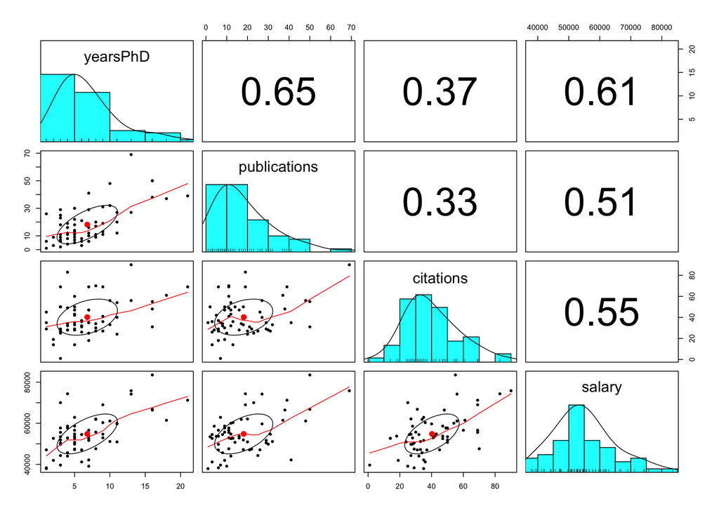

```r
publications %>%
  select(yearsPhD, publications, citations, salary) %>%
  pairs.panels()
```

# Plot boxplots of years since PhD, publications, citations, and salary by gender

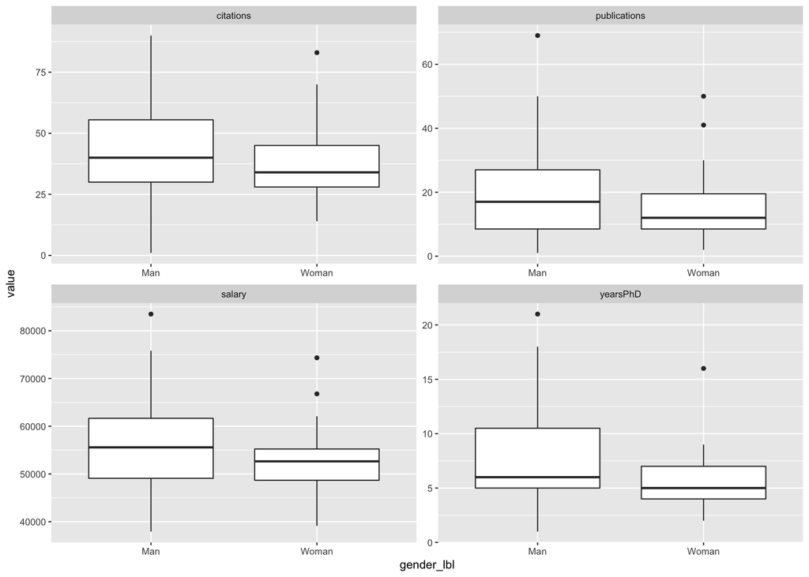

```r
publications %>%
  gather(key = variable, value = value, yearsPhD, publications, citations, salary) %>%
  ggplot(mapping = aes(x = gender_lbl, y = value)) +
  geom_boxplot() +
  facet_wrap(facets = ~ variable, scales = "free")
```

# Test whether men and women have equal average salaries

```r
t.test(salary ~ gender_lbl, data = publications)
```

```
##
##  Welch Two Sample t-test
##
## data:  salary by gender_lbl
## t = 1.6567, df = 59.753, p-value = 0.1028
## alternative hypothesis: true difference in means is not equal to 0
## 95 percent confidence interval:
##  -809.5813 8613.7697
## sample estimates:
##   mean in group Man mean in group Woman
##            56515.06            52612.96
```

# Estimate the relationship between publications and salary

> Report the estimate in salary units  
> What does the intercept mean?

## Fit the model

```r
lm.fit1 <- lm(salary ~ publications, data = publications)
```

## Generate diagnostic plots

> Is there a relationship between predicted values and residuals? (i.e., is there a pattern in the first plot?)  
> Do the resduals look normal? (i.e., the dots “hug” the line in the second plot)

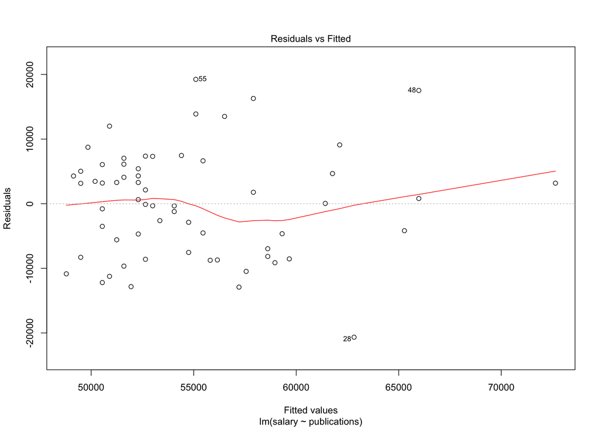

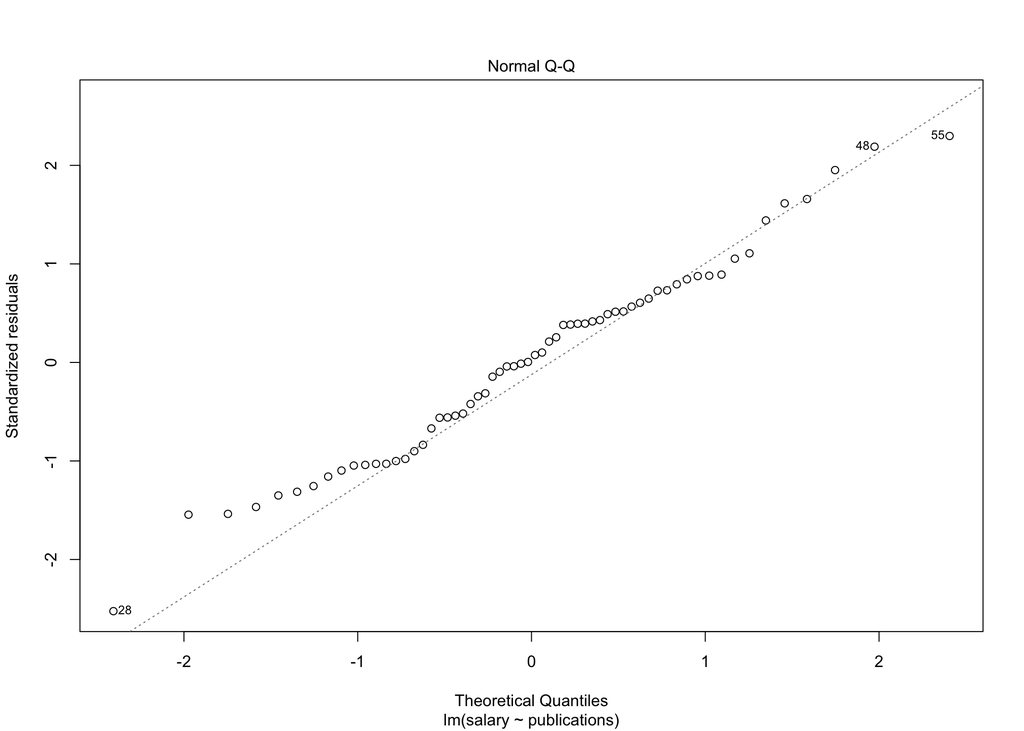

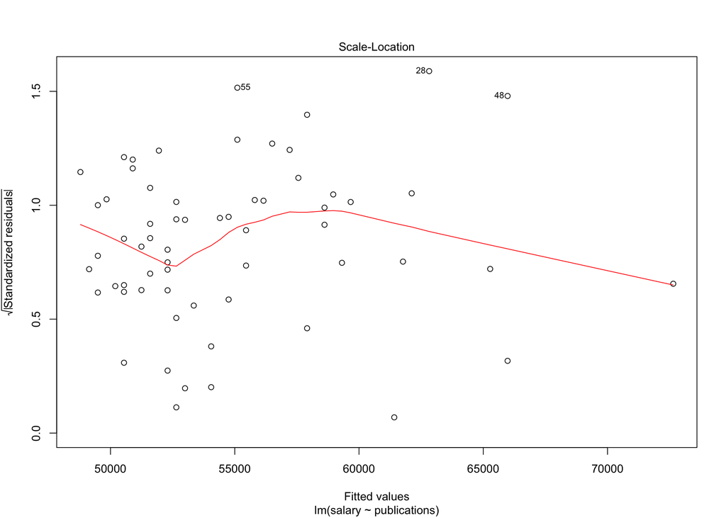

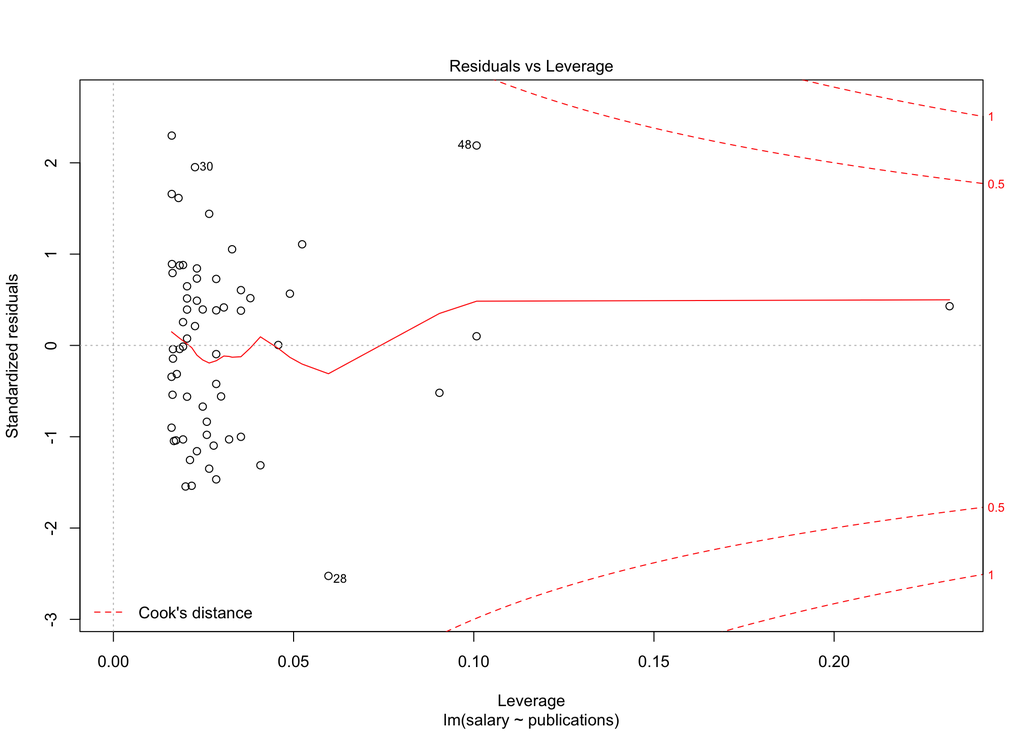

```r
plot(lm.fit1)
```

## Print results

```r
summary(lm.fit1)
```

```
##
## Call:
## lm(formula = salary ~ publications, data = publications)
##
## Residuals:
##      Min       1Q   Median       3Q      Max
## -20660.0  -7397.5    333.7   5313.9  19238.7
##
## Coefficients:
##              Estimate Std. Error t value Pr(>|t|)
## (Intercept)  48439.09    1765.42  27.438  < 2e-16 ***
## publications   350.80      77.17   4.546 2.71e-05 ***
## ---
## Signif. codes:  0 '***' 0.001 '**' 0.01 '*' 0.05 '.' 0.1 ' ' 1
##
## Residual standard error: 8440 on 60 degrees of freedom
## Multiple R-squared:  0.2562, Adjusted R-squared:  0.2438
## F-statistic: 20.67 on 1 and 60 DF,  p-value: 2.706e-05
```

# Visualize the relationship between publications and salary by gender

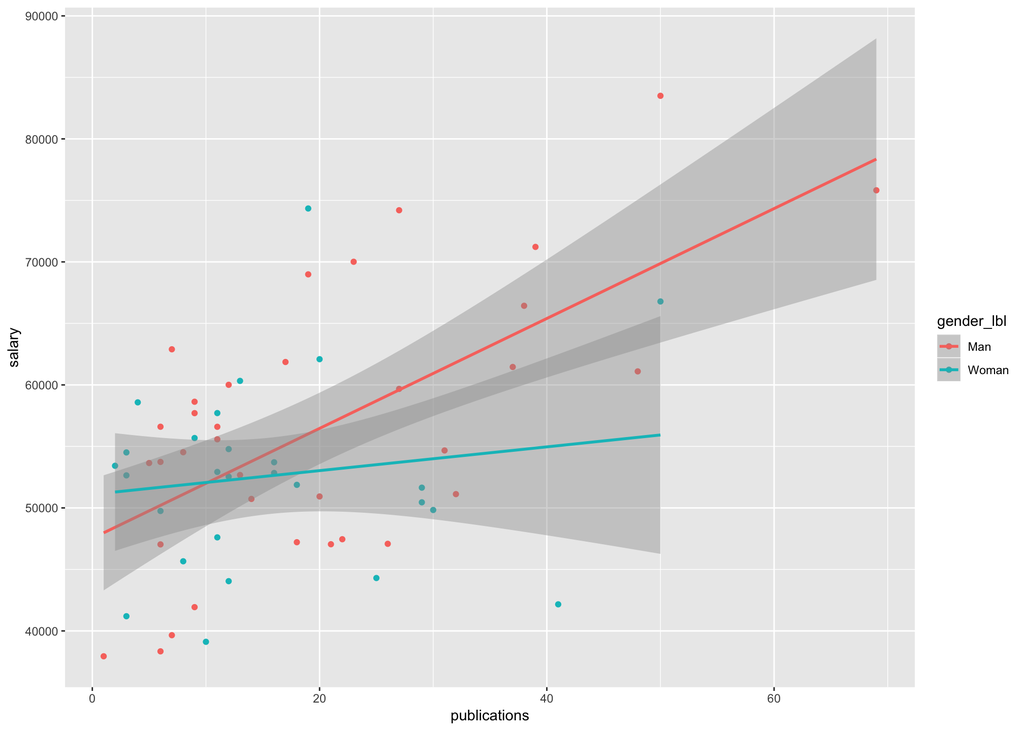

```r
publications %>%
  ggplot(mapping = aes(x = publications, y = salary, color = gender_lbl)) +
  geom_point() +
  geom_smooth(method = "lm")
```

## Mean center the publications variable

> Subtract the mean of publications from each publications value.

```r
publications$publications_c <- with(data = publications, publications - mean(publications))
```

## Replot the relationship with the centered publication variable

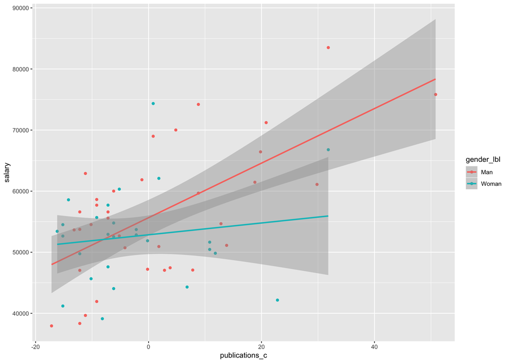

```r
publications %>%
  ggplot(mapping = aes(x = publications_c, y = salary, color = gender_lbl)) +
  geom_point() +
  geom_smooth(method = "lm")
```

# Estimate the relationship between publications and salary and whether it depends on gender

> Use the mean-centered publications variable  
> Report the estimate in salary units  
> What does the coefficient for gender mean?  
> What does the intercept mean?

## Fit the model

```r
lm.fit2 <- lm(salary ~ publications_c * man, data = publications)
```

## Generate diagnostic plots

> Is there a relationship between predicted values and residuals? (i.e., is there a pattern in the first plot?)  
> Do the resduals look normal? (i.e., the dots “hug” the line in the second plot)

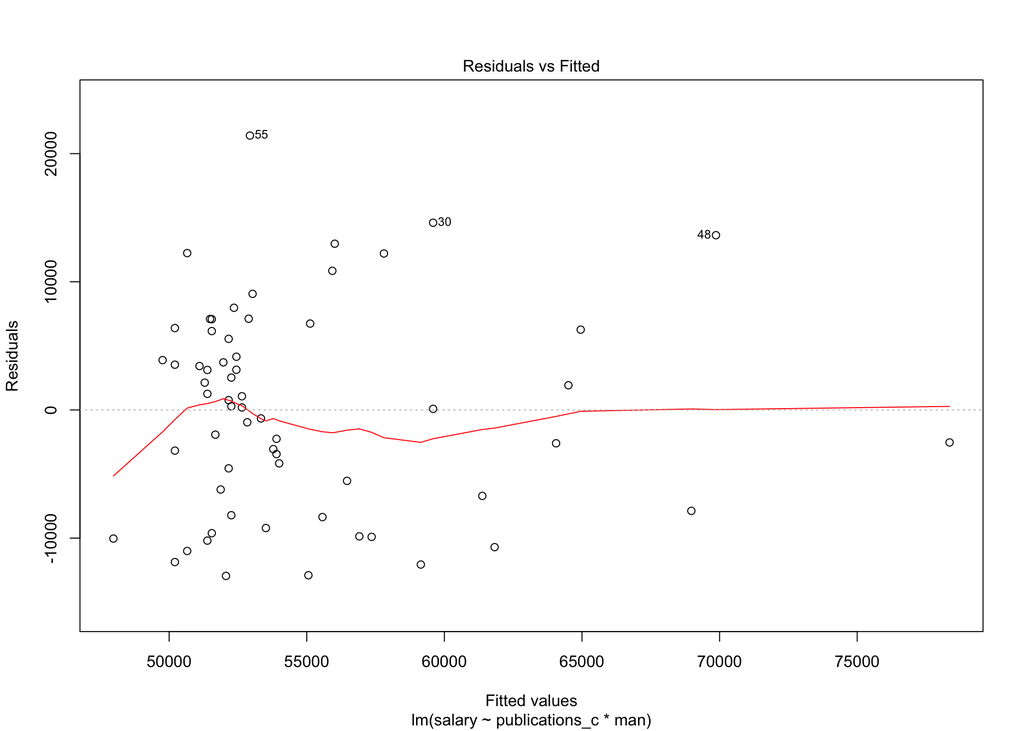

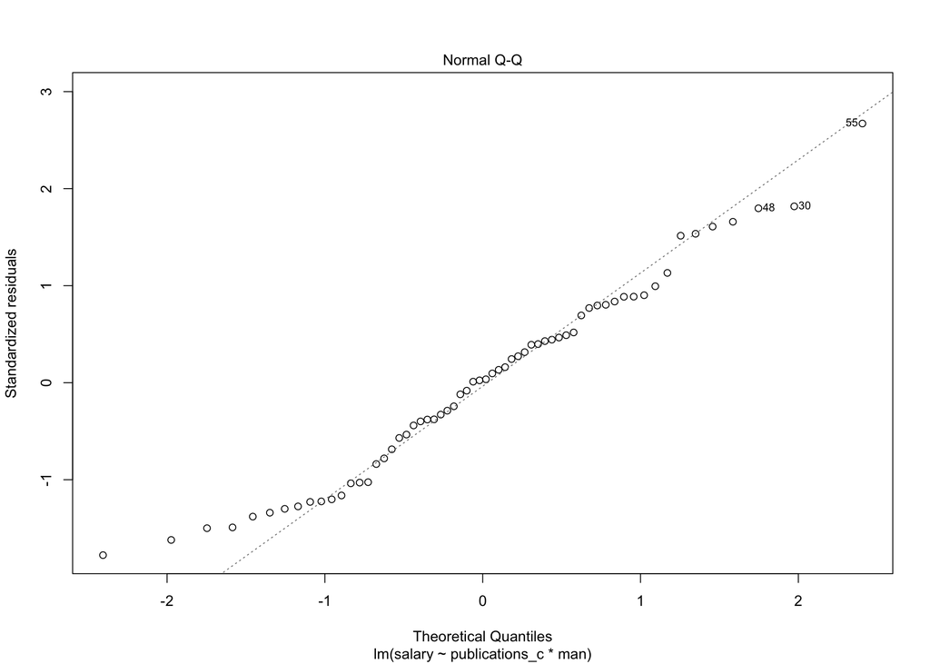

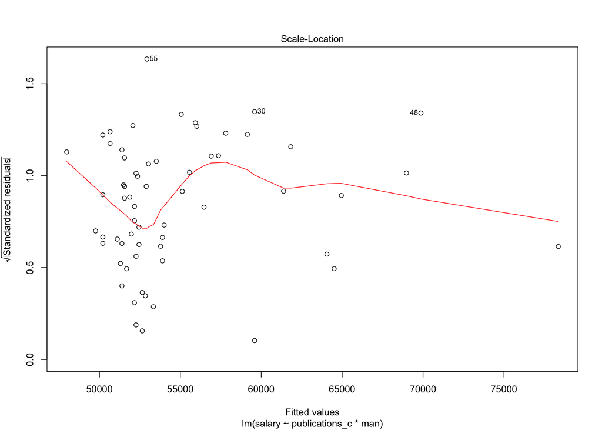

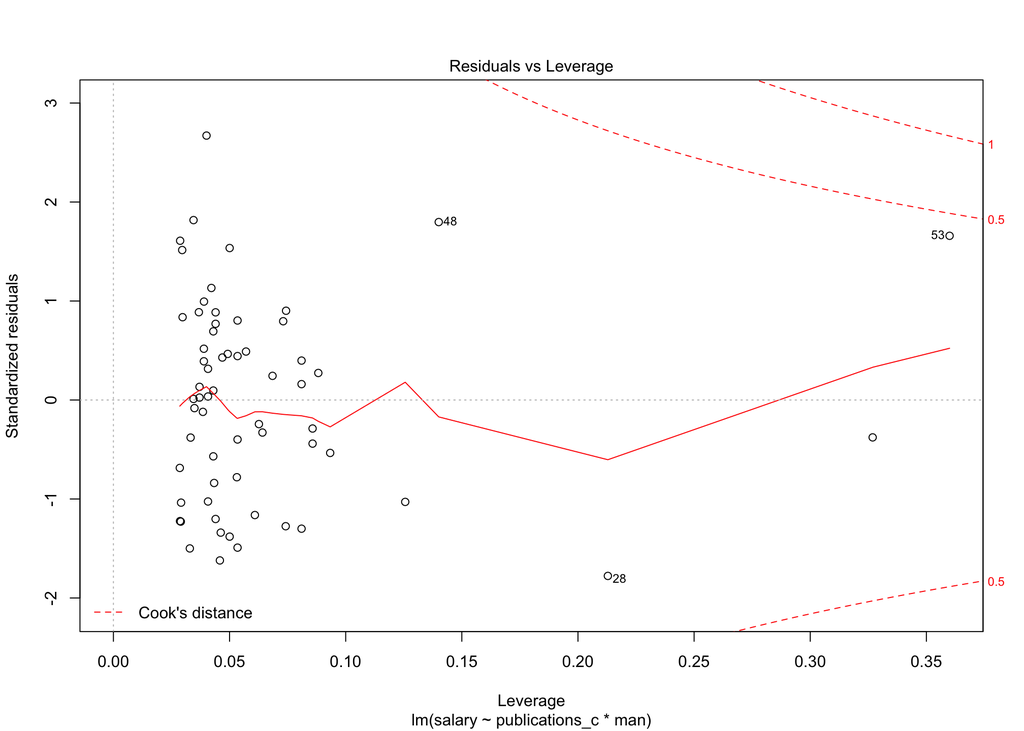

```r
plot(lm.fit2)
```

## Save the cook’s distance values to your dataset

> 1. Create a new variable in dataset called “cooks.d2” (i.e., cook’s distance values for the second model)
> 2. See help(“cooks.distance”)

```r
publications$cooks.d2 <- cooks.distance(lm.fit2)
```

## Plot cook’s distance values on the y-axis and id1 on the y-axis

> Cook’s distance indexes the influence of an observation on the regression: bigger values mean including that observation had a bigger effect on the regression results  
> Looking at the plot, are there any influential observations?

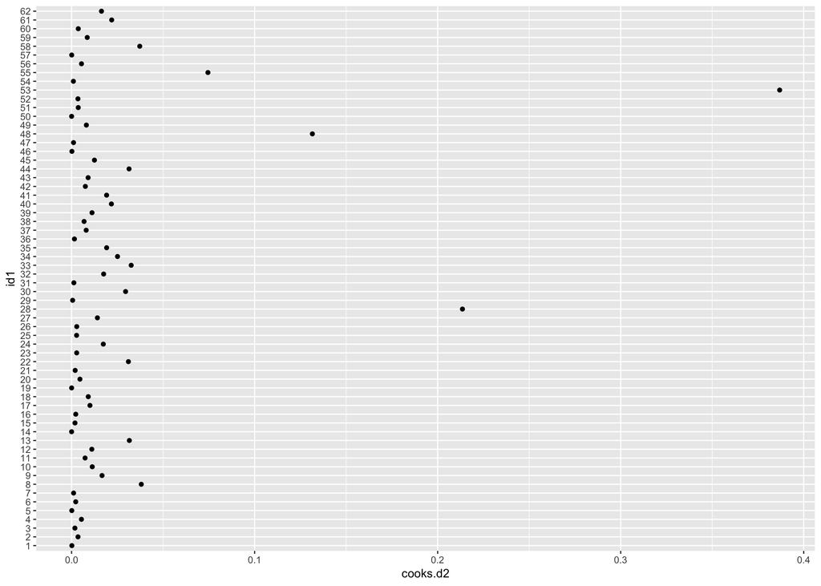

```r
publications %>%
  ggplot(mapping = aes(x = id1, y = cooks.d2)) +
  geom_point() +
  coord_flip()
```

## Print results

```r
summary(lm.fit2)
```

```
##
## Call:
## lm(formula = salary ~ publications_c * man, data = publications)
##
## Residuals:
##    Min     1Q Median     3Q    Max
## -12950  -6583    239   6003  21408
##
## Coefficients:
##                    Estimate Std. Error t value Pr(>|t|)
## (Intercept)        54252.59    1065.03  50.940  < 2e-16 ***
## publications_c       271.70      81.68   3.326  0.00153 **
## man                 2794.16    2130.07   1.312  0.19477
## publications_c:man   350.19     163.36   2.144  0.03626 *
## ---
## Signif. codes:  0 '***' 0.001 '**' 0.01 '*' 0.05 '.' 0.1 ' ' 1
##
## Residual standard error: 8180 on 58 degrees of freedom
## Multiple R-squared:  0.3246, Adjusted R-squared:  0.2897
## F-statistic: 9.293 on 3 and 58 DF,  p-value: 4.132e-05
```